# MLS4001: Estatística Aplicada à Medicina

Aula 01: Explorando Dados

José O Siqueira (siqueira@usp.br) Paulo SP Silveira (silveira@usp.br)

05 agosto 2023 18:46h

```r
options(warn=-1)
suppressMessages(library(knitr, warn.conflicts=FALSE))
suppressMessages(library(readxl, warn.conflicts=FALSE))
Sys.setlocale("LC_CTYPE", "pt_BR.UTF-8")
```

```
[1] "pt_BR.UTF-8"
```

```r
Sys.setlocale("LC_ALL", "pt_BR.UTF-8")
```

```
[1] "LC_COLLATE=pt_BR.UTF-8;LC_CTYPE=pt_BR.UTF-8;LC_MONETARY=pt_BR.UTF-8;LC_NUMERIC=C;LC_TIME=pt_BR.UTF-8"
```

# Quatro problemas

- Ler e descrever `Biometria_FMUSP.xlsx`
- Ler e transformar a estrutura de dados de `NewDrug.xlsx` de formato *wide* para *long* e vice-versa
- Ler dados em colunas e tabelas dentro de script R
- Ler e descrever arquivo de dados grande `DOBR2020.dbc` (documentação em `Estrutura_SIM_para_CD.pdf`)

# Ler e descrever `Biometria_FMUSP.xlsx`

A primeira etapa é ler os dados, ver como estão, consertá-los e preparar para futura análise. A íntegra deste R *script* está em `Biometria_arruma.R`.

Este R *script*:

- le o arquivo em formato Excel:

```r
dados <- readxl::read_excel("Biometria_FMUSP.xlsx")
knitr::kable(head(dados), format="html", caption="Biometria FMUSP")
```

Biometria FMUSP

ID

Ano

Turma

Sexo

Mao

TipoSang

ABO

AtivFisica

Sedentarismo

MCT

Estatura

Rh

1

2

B

M

D

A+

A

baixa_intensidade

N

68

173

2

2

B

M

D

A+

A

atualmente_inativo

S

82

175

3

1

B

M

D

A+

A

media_intensidade

N

79

172

4

1

B

F

D

A+

A

media_intensidade

N

49

160

5

1

B

F

D

O-

O

atualmente_inativo

S

52

164

6

3

A

M

D

A+

A

alta_intensidade

N

73

175

```r
knitr::kable(tail(dados), format="html", caption="Biometria FMUSP")
```

Biometria FMUSP

ID

Ano

Turma

Sexo

Mao

TipoSang

ABO

AtivFisica

Sedentarismo

MCT

Estatura

Rh

544

3

B

F

C

NA

NA

alta_intensidade

N

54

157

NA

545

3

B

F

D

B+

B

alta_intensidade

N

47

157

546

3

B

F

D

B+

B

sempre_inativo

S

48

162

547

3

B

M

A

A+

A

alta_intensidade

N

70

175

548

3

B

M

D

O-

O

atualmente_inativo

S

67

171

549

3

B

F

D

A+

A

media_intensidade

N

45

160

mostra quais sao as colunas:

```r
print(names(dados))
```

```
 [1] "ID"           "Ano"          "Turma"        "Sexo"         "Mao"          "TipoSang"     "ABO"          "AtivFisica"   "Sedentarismo" "MCT"          "Estatura"     "Rh"
```

- verifica a estrutura de dados:

```r
print(str(dados))
```

```
tibble [549 × 12] (S3: tbl_df/tbl/data.frame)
 $ ID          : num [1:549] 1 2 3 4 5 6 7 8 9 10 ...
 $ Ano         : num [1:549] 2 2 1 1 1 3 3 2 3 3 ...
 $ Turma       : chr [1:549] "B" "B" "B" "B" ...
 $ Sexo        : chr [1:549] "M" "M" "M" "F" ...
 $ Mao         : chr [1:549] "D" "D" "D" "D" ...
 $ TipoSang    : chr [1:549] "A+" "A+" "A+" "A+" ...
 $ ABO         : chr [1:549] "A" "A" "A" "A" ...
 $ AtivFisica  : chr [1:549] "baixa_intensidade" "atualmente_inativo" "media_intensidade" "media_intensidade" ...
 $ Sedentarismo: chr [1:549] "N" "S" "N" "N" ...
 $ MCT         : chr [1:549] "68" "82" "79" "49" ...
 $ Estatura    : chr [1:549] "173" "175" "172" "160" ...
 $ Rh          : chr [1:549] "+" "+" "+" "+" ...
NULL
```

Executando-se este procedimento temos:

```r
source("Biometria_arruma.R")
```

```
Nomes das variáveis:
 [1] "ID"           "Ano"          "Turma"        "Sexo"         "Mao"          "TipoSang"     "ABO"          "AtivFisica"   "Sedentarismo" "MCT"          "Estatura"     "Rh"

Estrutura:
tibble [549 × 12] (S3: tbl_df/tbl/data.frame)
 $ ID          : num [1:549] 1 2 3 4 5 6 7 8 9 10 ...
 $ Ano         : num [1:549] 2 2 1 1 1 3 3 2 3 3 ...
 $ Turma       : chr [1:549] "B" "B" "B" "B" ...
 $ Sexo        : chr [1:549] "M" "M" "M" "F" ...
 $ Mao         : chr [1:549] "D" "D" "D" "D" ...
 $ TipoSang    : chr [1:549] "A+" "A+" "A+" "A+" ...
 $ ABO         : chr [1:549] "A" "A" "A" "A" ...
 $ AtivFisica  : chr [1:549] "baixa_intensidade" "atualmente_inativo" "media_intensidade" "media_intensidade" ...
 $ Sedentarismo: chr [1:549] "N" "S" "N" "N" ...
 $ MCT         : chr [1:549] "68" "82" "79" "49" ...
 $ Estatura    : chr [1:549] "173" "175" "172" "160" ...
 $ Rh          : chr [1:549] "+" "+" "+" "+" ...
NULL

Converte em fatores:

     Ano : [1] "2" "1" "3"
tibble [549 × 1] (S3: tbl_df/tbl/data.frame)
 $ Ano: Factor w/ 3 levels "1","2","3": 2 2 1 1 1 3 3 2 3 3 ...
NULL

     Turma : [1] "B" "A"
tibble [549 × 1] (S3: tbl_df/tbl/data.frame)
 $ Turma: Factor w/ 2 levels "A","B": 2 2 2 2 2 1 1 2 2 2 ...
NULL

     Sexo : [1] "M" "F"
tibble [549 × 1] (S3: tbl_df/tbl/data.frame)
 $ Sexo: Factor w/ 2 levels "F","M": 2 2 2 1 1 2 2 2 2 2 ...
NULL

     Mao : [1] "D"  "A"  "C"  "NA"
tibble [549 × 1] (S3: tbl_df/tbl/data.frame)
 $ Mao: Factor w/ 4 levels "A","C","D","NA": 3 3 3 3 3 3 3 3 3 3 ...
NULL
```

[output cut: 154 more lines]

```
 Mean   :170.8
 3rd Qu.:177.0
 Max.   :195.0
 NA's   :6

 Rh :
    Rh
 -   :130
 +   :408
 NA's: 11

Graficos e tabelas iniciais:
Ano
  1   2   3
171 155 223
```

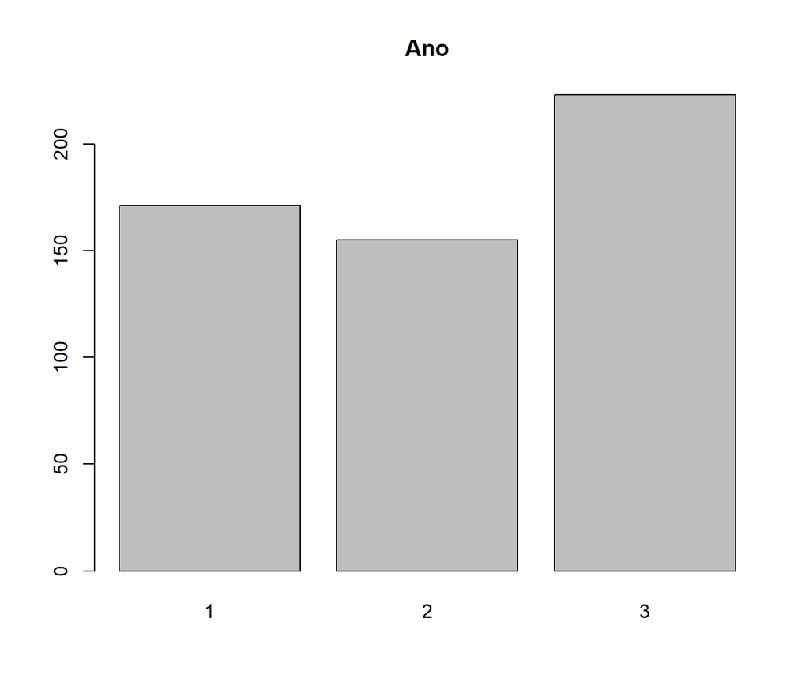

```
Turma
  A   B
285 264
```

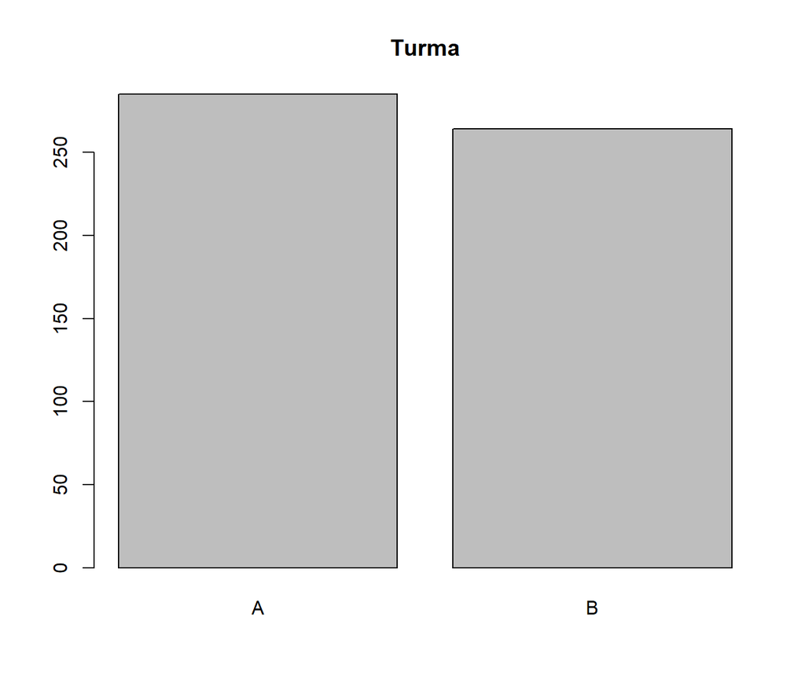

```
Sexo
  F   M
232 317
```

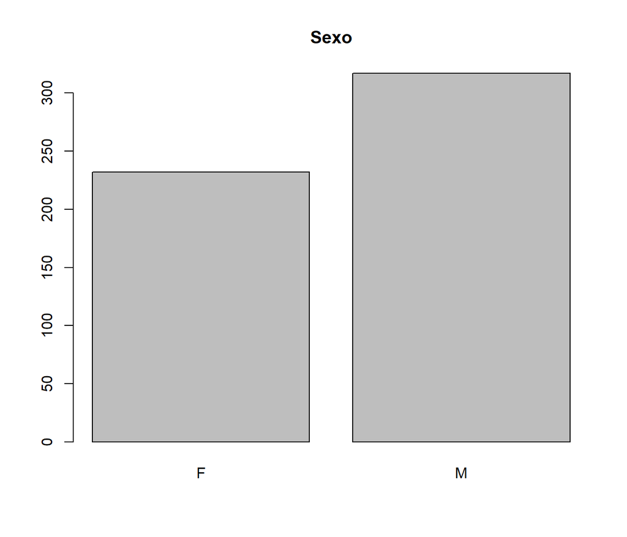

```
Mao
  A   C   D
 28  37 442
```

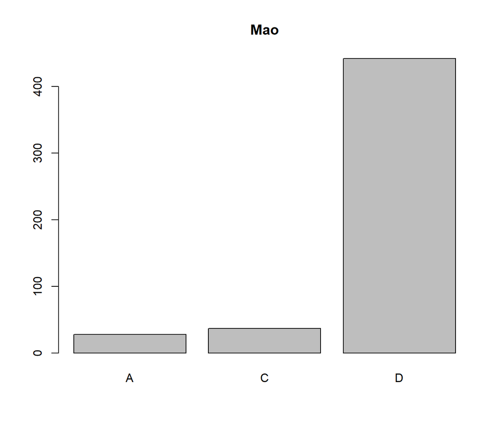

```
TipoSang
 A-  A+ AB- AB+  B-  B+  O-  O+
 49 171   2  40  34  65  45 132
```

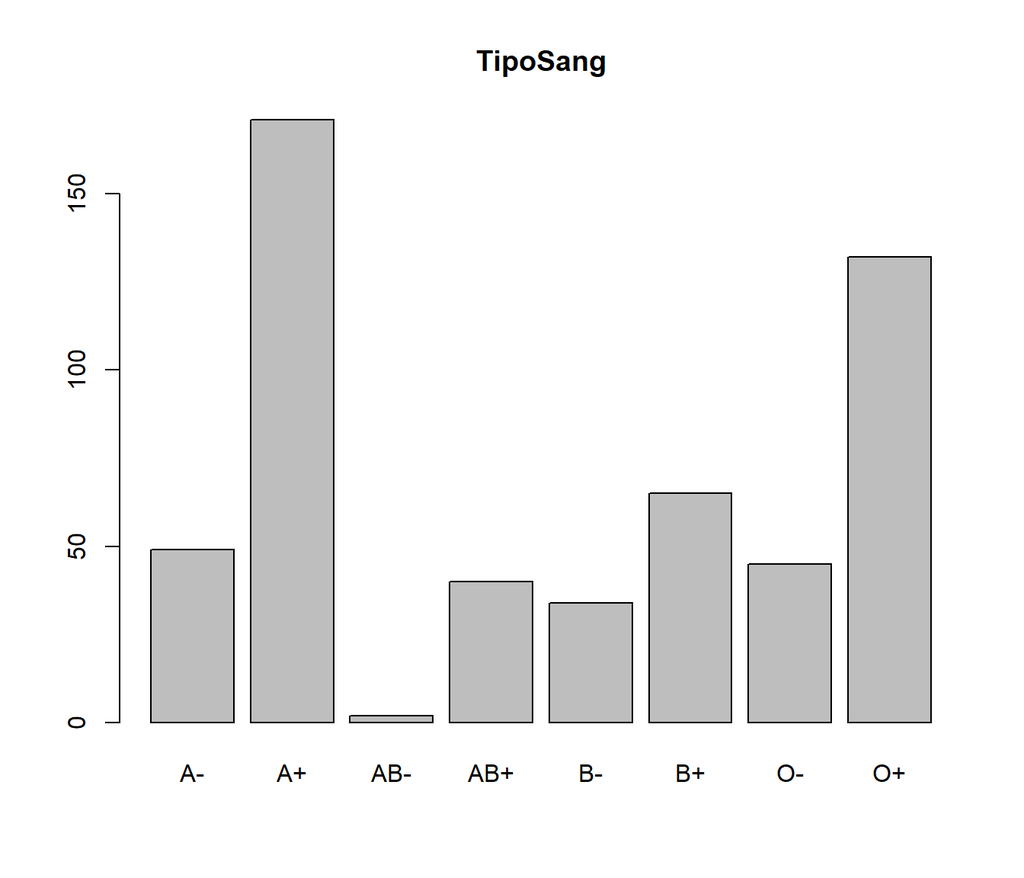

```
ABO
  A  AB   B   O
220  42  99 177
```

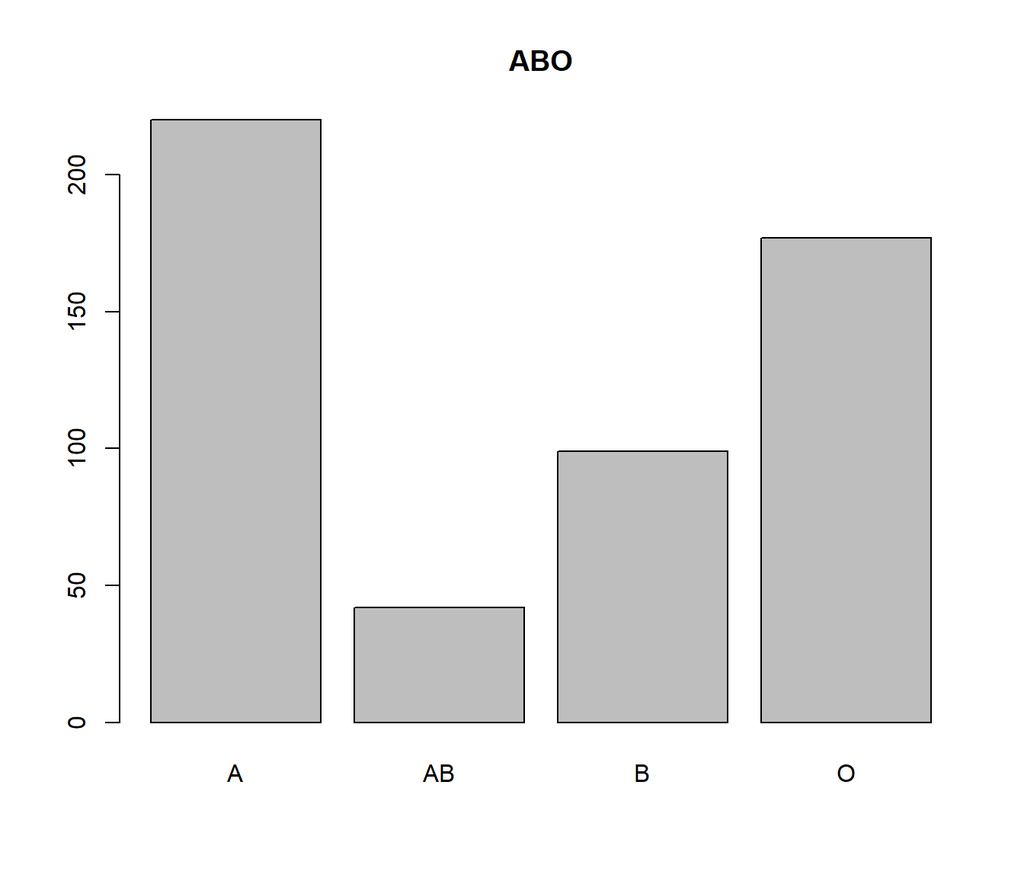

```
AtivFisica
 SI  AI   B   M   A
 71 152  59  99 168
```

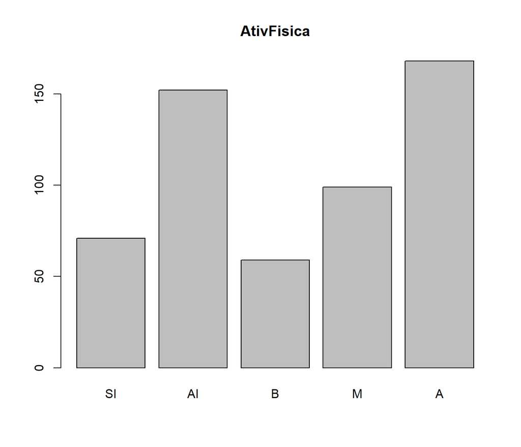

```
Sedentarismo
  N   S
316 233
```

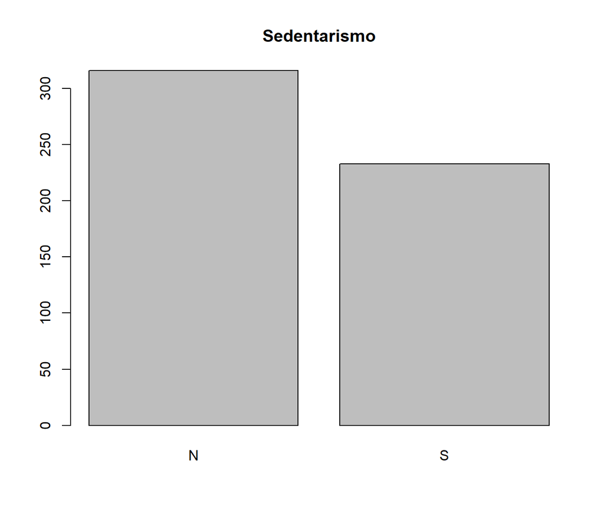

```
Rh
  -   +
130 408
```

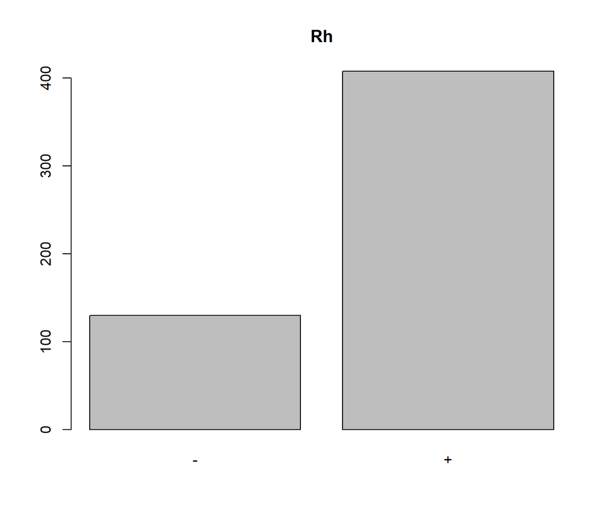

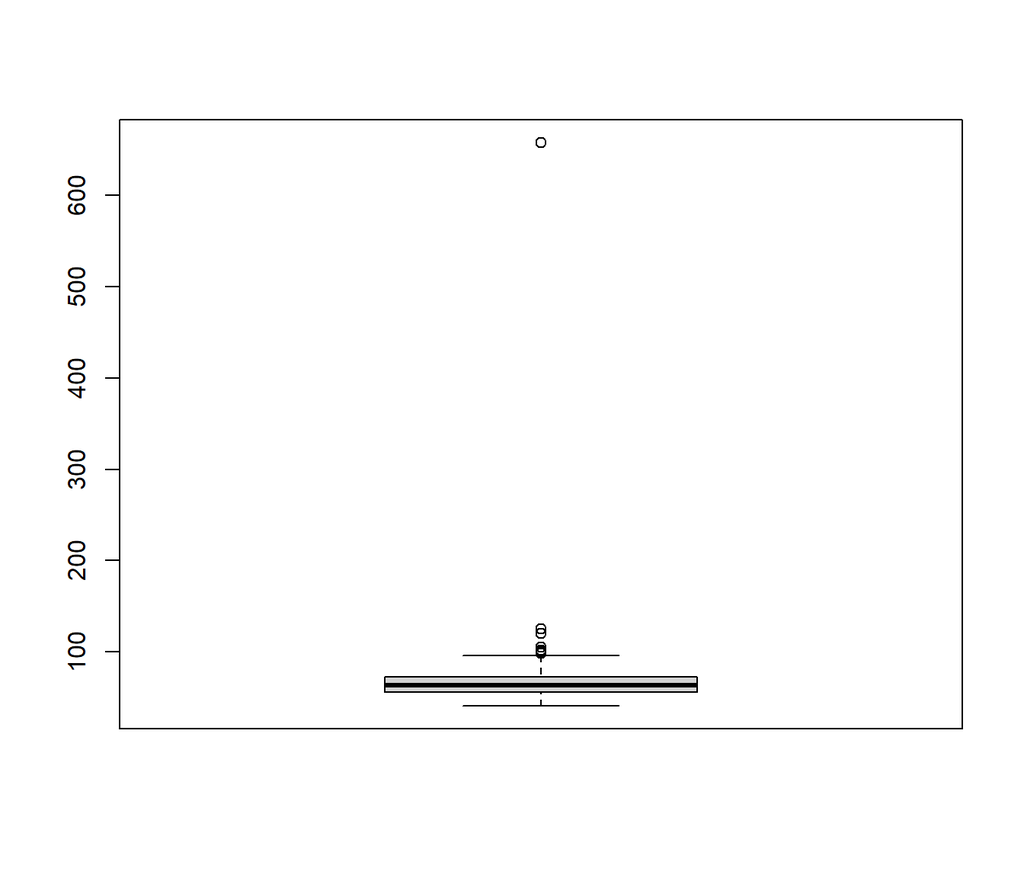

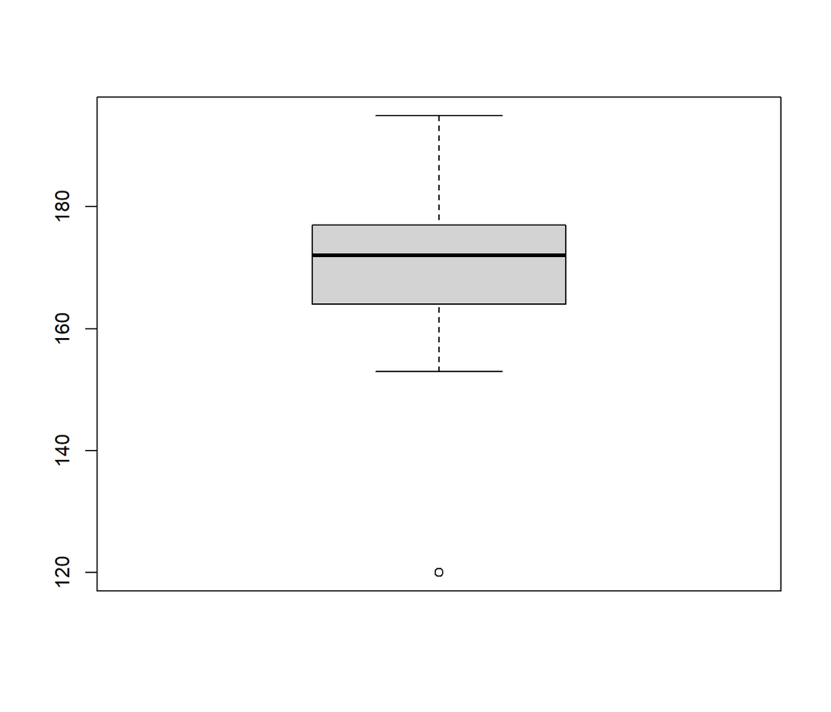

```
Individuo com mais que 600 kg
# A tibble: 1 × 12
  ID    Ano   Turma Sexo  Mao   TipoSang ABO   AtivFisica Sedentarismo   MCT Estatura Rh
  <chr> <fct> <fct> <fct> <fct> <fct>    <fct> <fct>      <fct>        <dbl>    <dbl> <fct>
1 181   1     B     M     D     B+       B     M          N              658      178 +

Individuo com massa e estatura iguais a 120
# A tibble: 1 × 12
  ID    Ano   Turma Sexo  Mao   TipoSang ABO   AtivFisica Sedentarismo   MCT Estatura Rh
  <chr> <fct> <fct> <fct> <fct> <fct>    <fct> <fct>      <fct>        <dbl>    <dbl> <fct>
1 464   3     B     F     D     A+       A     A          N              120      120 +

Optamos por remover os dados incorretos, restando:
- MCT:
   Min. 1st Qu.  Median    Mean 3rd Qu.    Max.    NA's
  41.00   56.00   64.00   65.67   73.00  125.00       7

- Estatura:
   Min. 1st Qu.  Median    Mean 3rd Qu.    Max.    NA's
  153.0   164.0   172.0   170.9   177.0   195.0       7
```

Com os dados arrumados, uma primeira análise descritiva é feita com `Biometria_descreve.R`. Este procedimento relê a planilha para análise do anterior, mostrando que há informações perdidas sobre os tipos de variável no Excel (é necessário refazer) e, então, grava os resultados em dois arquivos:

- `DescreveBiometria.txt` com as saídas textuais
- `DescreveBiometria.pdf` com os gráficos

Este é o jeito mais simples, embora rudimentar, de produzir saídas do R.

É necessário, então, analisar cada variável, em busca de valores atípicos ou outros problemas nos dados. Ao final deste processo teremos um conjunto de dados “curado”, que pode ser analisado mais confiavelmente.

|  | Para mostrar a saída de `Biometria_descreve.R` aqui, foi incluída uma variável lógica, `gravar <- FALSE`. Altere para `gravar <- TRUE` se quiser gerar os arquivos mencionados. |
| --- | --- |

A saída de `Biometria_descreve.R` é:

```r
source("Biometria_descreve.R")
```

```
Nomes dos campos:
 [1] "ID"           "Ano"          "Turma"        "Sexo"         "Mao"          "TipoSang"     "ABO"          "AtivFisica"   "Sedentarismo" "MCT"          "Estatura"     "Rh"

Estrutura:
tibble [549 × 12] (S3: tbl_df/tbl/data.frame)
 $ ID          : chr [1:549] "1" "2" "3" "4" ...
 $ Ano         : Factor w/ 3 levels "1","2","3": 2 2 1 1 1 3 3 2 3 3 ...
 $ Turma       : Factor w/ 2 levels "A","B": 2 2 2 2 2 1 1 2 2 2 ...
 $ Sexo        : Factor w/ 2 levels "F","M": 2 2 2 1 1 2 2 2 2 2 ...
 $ Mao         : Factor w/ 3 levels "A","C","D": 3 3 3 3 3 3 3 3 3 3 ...
 $ TipoSang    : Factor w/ 8 levels "A-","A+","AB-",..: 2 2 2 2 7 2 2 6 8 8 ...
 $ ABO         : Factor w/ 4 levels "A","AB","B","O": 1 1 1 1 4 1 1 3 4 4 ...
 $ AtivFisica  : Factor w/ 5 levels "SI","AI","B",..: 3 2 4 4 2 5 5 4 5 5 ...
 $ Sedentarismo: Factor w/ 2 levels "N","S": 1 2 1 1 2 1 1 1 1 1 ...
 $ MCT         : num [1:549] 68 82 79 49 52 73 73 60 75 75 ...
 $ Estatura    : num [1:549] 173 175 172 160 164 175 175 173 182 182 ...
 $ Rh          : Factor w/ 2 levels "-","+": 2 2 2 2 1 2 2 2 2 2 ...
NULL

--------------------
Ano
  1   2   3
171 155 223
```

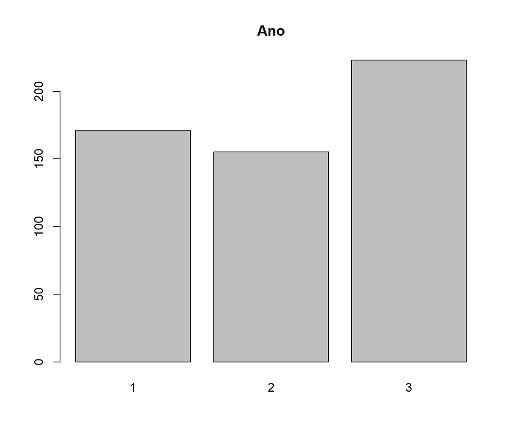

```
--------------------
Turma
  A   B
285 264
```

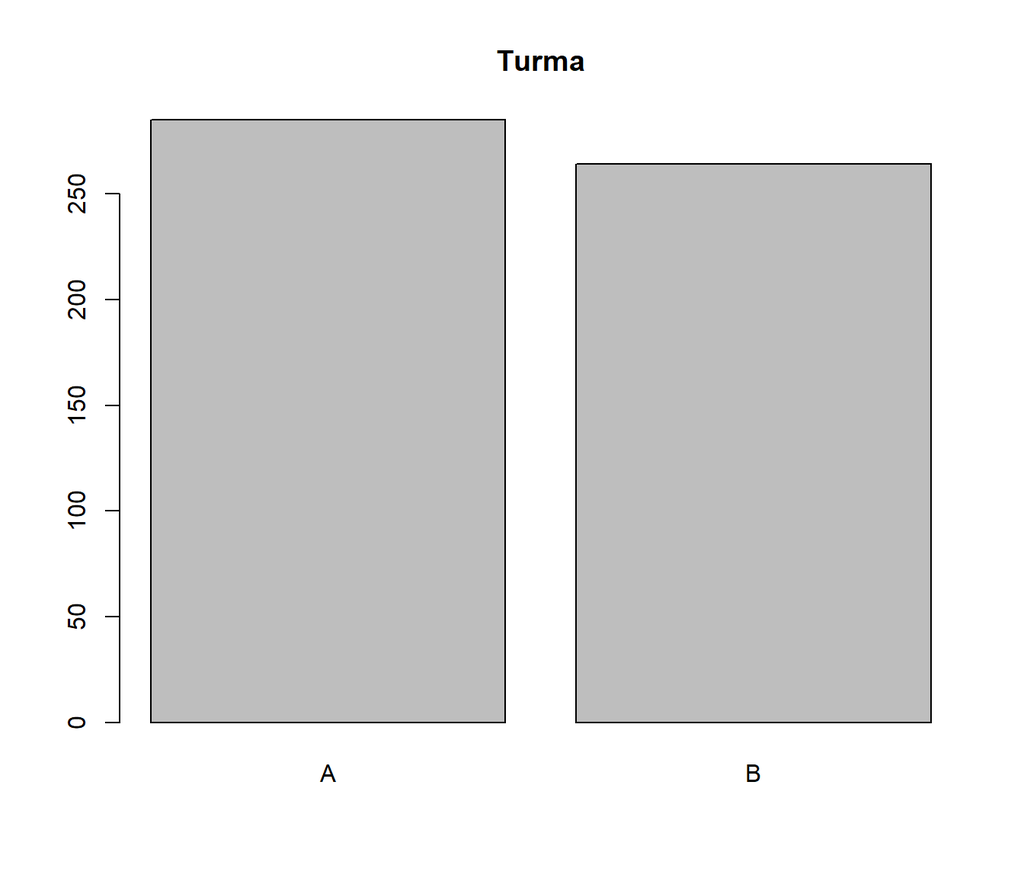

```
--------------------
Sexo
  F   M
232 317
```

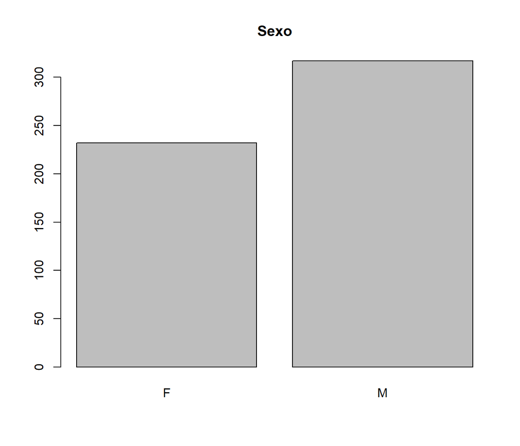

```
--------------------
Mao
  A   C   D
 28  37 442
```

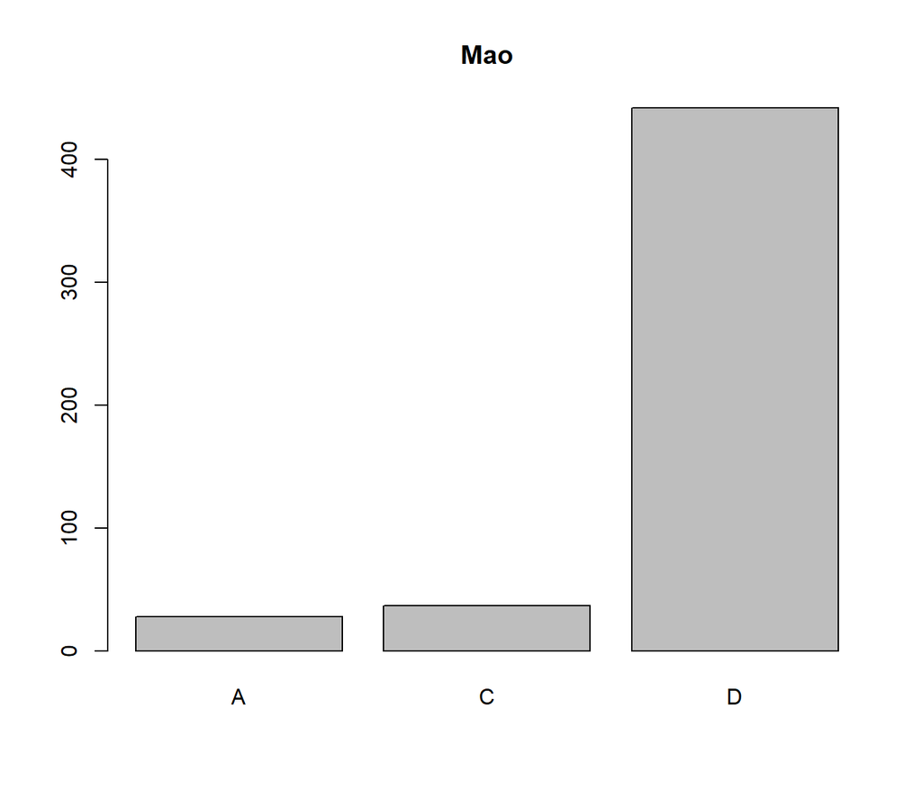

```
--------------------
TipoSang
 A-  A+ AB- AB+  B-  B+  O-  O+
 49 171   2  40  34  65  45 132
```

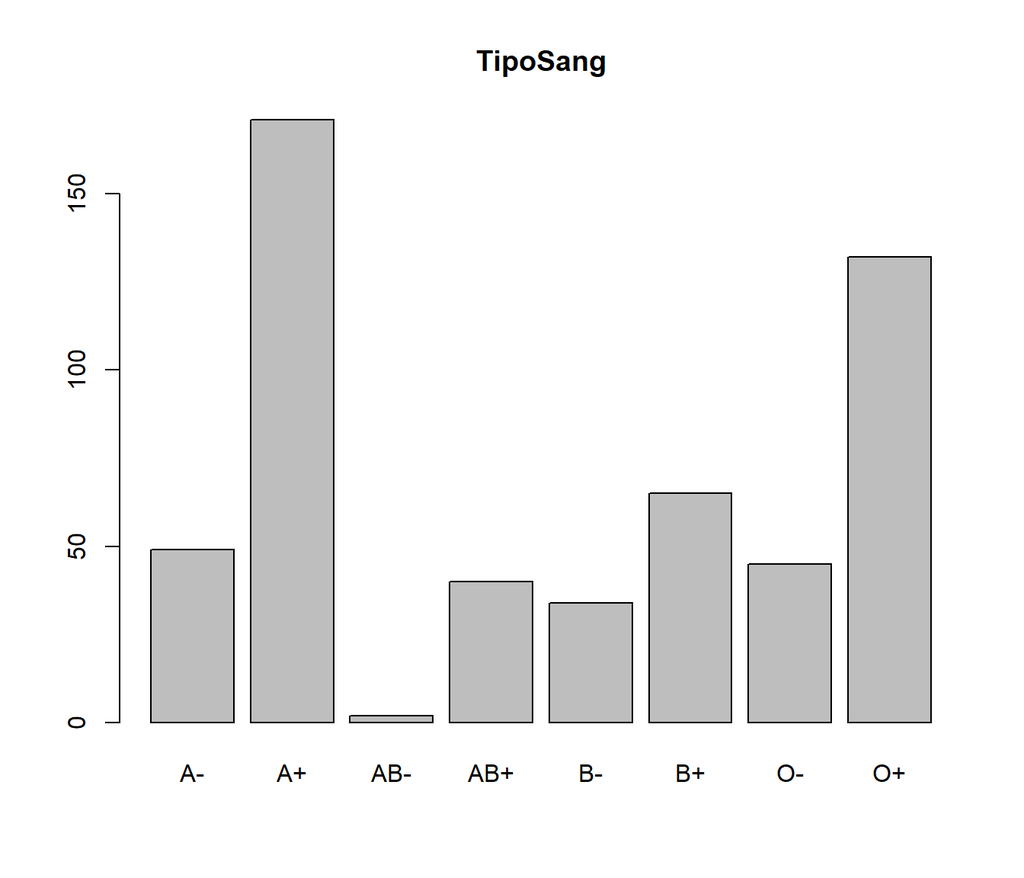

```
--------------------
ABO
  A  AB   B   O
220  42  99 177
```

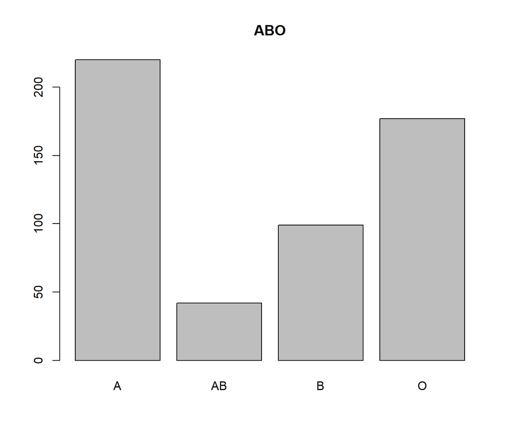

```
--------------------
AtivFisica
 SI  AI   B   M   A
 71 152  59  99 168
```

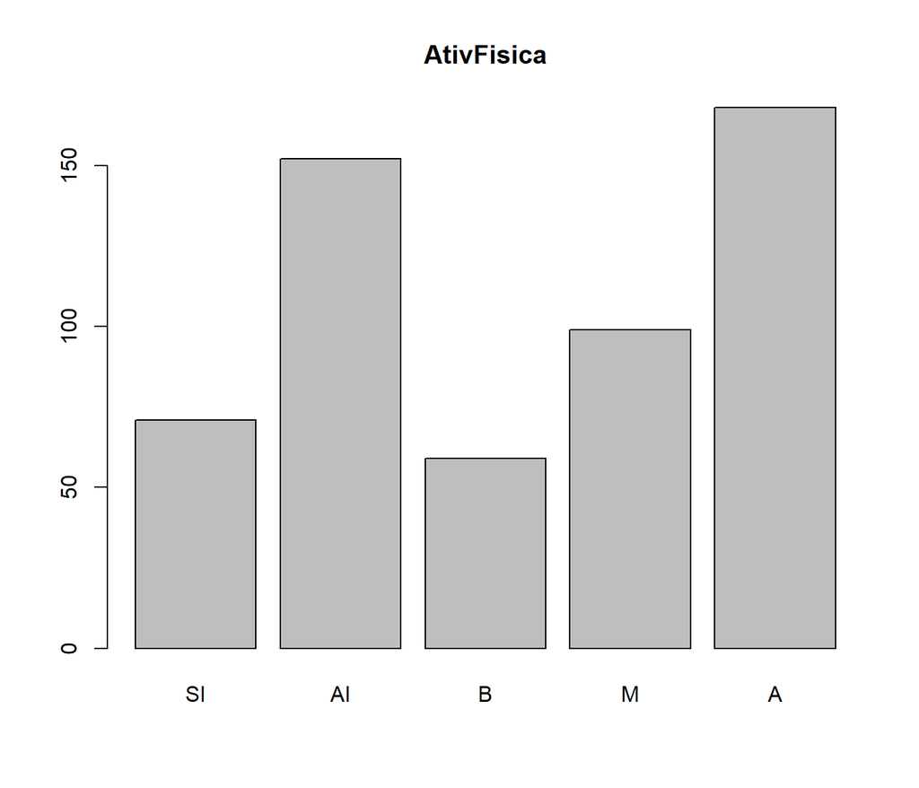

```
--------------------
Sedentarismo
  N   S
316 233
```

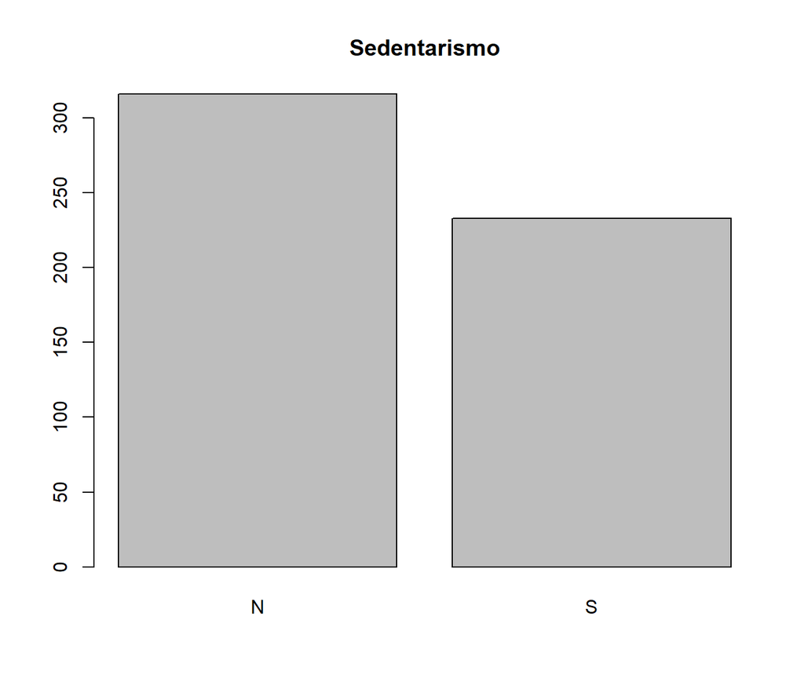

```
--------------------
Rh
  -   +
130 408
```

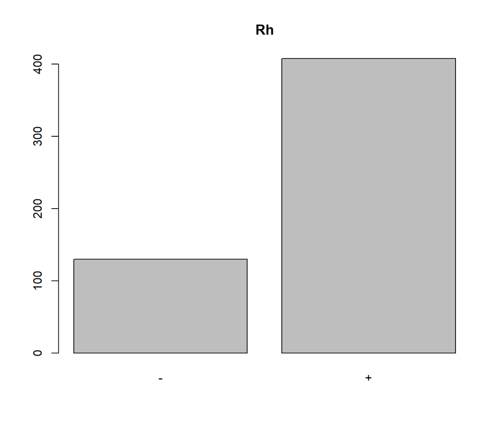

```
--------------------
MCT
   Min. 1st Qu.  Median    Mean 3rd Qu.    Max.    NA's
  41.00   56.00   64.00   65.67   73.00  125.00       7
```

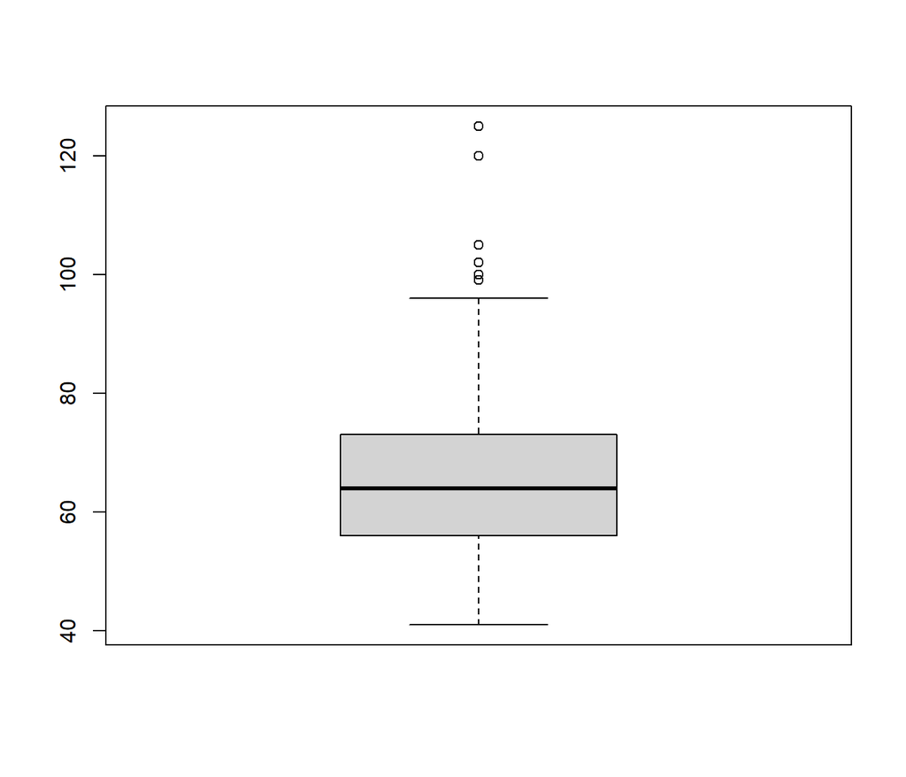

```
--------------------
Estatura
   Min. 1st Qu.  Median    Mean 3rd Qu.    Max.    NA's
  153.0   164.0   172.0   170.9   177.0   195.0       7
```

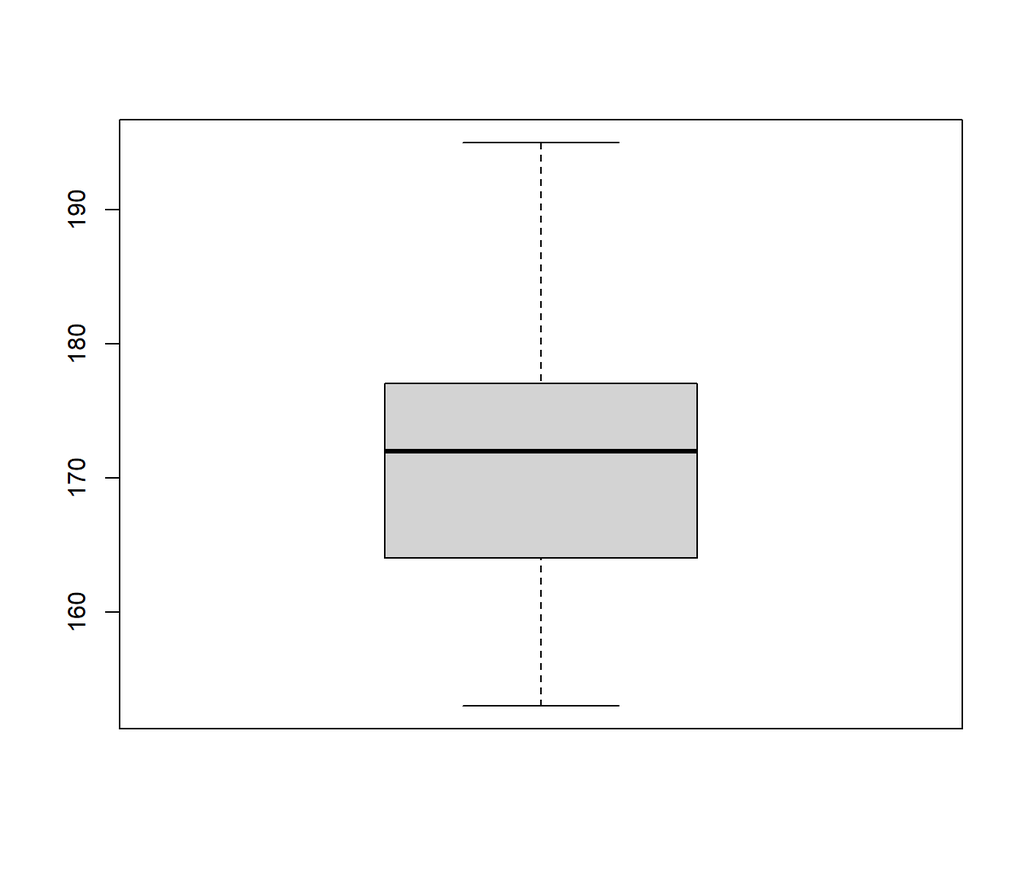